Nada Ardelia  
G1401231011

# White Noise

White Noise dibangkitkan dari peubah acak (set seed 4 digit akhir NIM)

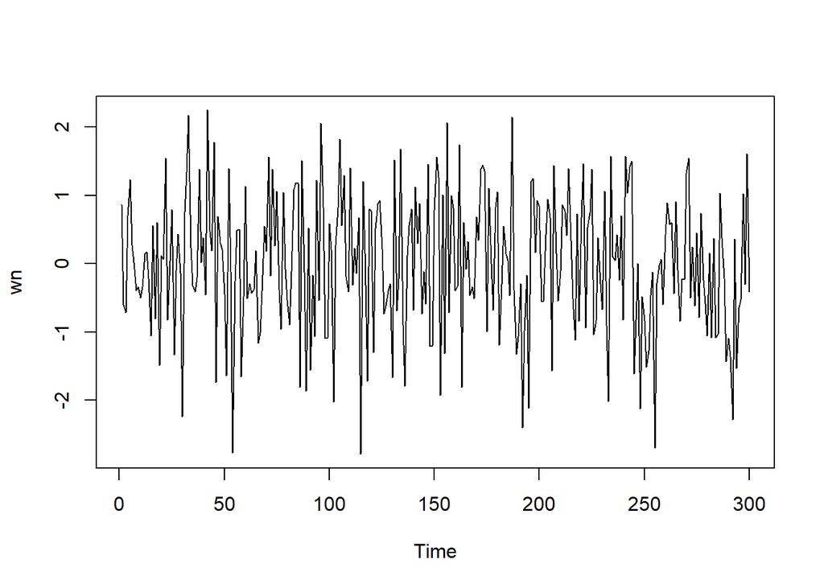

```r
set.seed(1011)
wn <- rnorm(300)
ts.plot(wn)
```

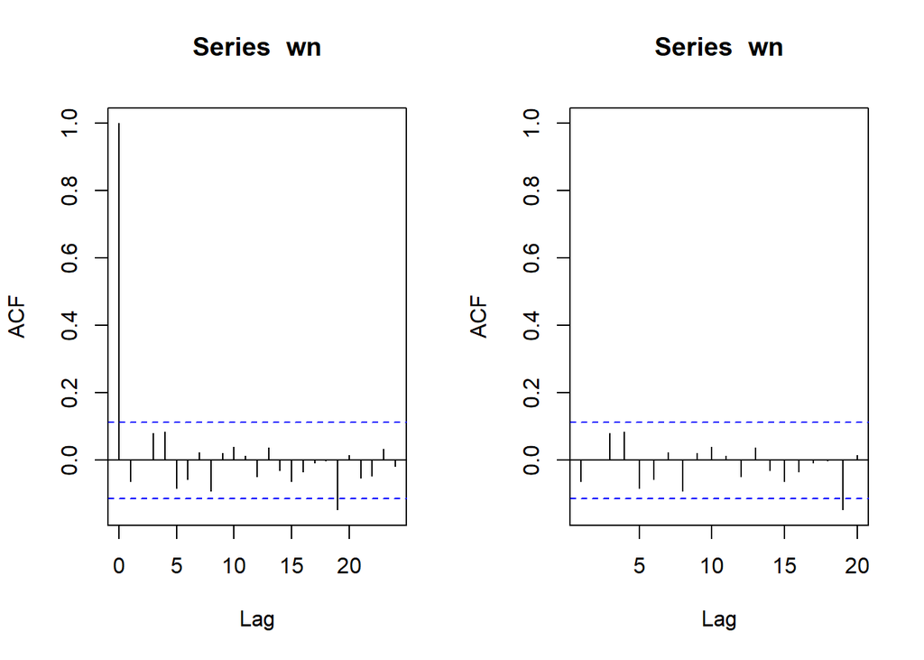

```r
par(mfrow = c(1, 2))
acf(wn)
acf(wn, xlim = c(1, 20))
```

Dapat dilihat bahwa white noise tidak memiliki autokorelasi dari plot ACF.

# MA(2)

$$y_t = c + e_t + \theta_1 e_{t-1} + \theta_2 e_{t-2}$$

## Model

```r
set.seed(1011)
ma <- rep(0, 300)
```

$$y_t = e_t + 0.4 e_{t-1} + 0.6 e_{t-2}$$

Nilai-nilai $y_t$ selanjutnya dapat dicari melalui *loop* berdasarkan rumus di atas.

```r
for(i in 3:300){
  ma[i] <- wn[i] + 0.4*wn[i-1] + 0.6*wn[i-2]
}

ma
```

```
##   [1]  0.0000000000  0.0000000000 -0.4378027692  0.0495337742  1.0796257905
##   [6]  1.1768394330  0.8609250155 -0.2279847473 -0.4928789504 -0.8776346986
##  [11] -0.7504264505 -0.2940564597  0.0273416539 -0.0550745453 -1.0344468771
##  [16]  0.0095155322 -1.2196096623  0.6161208229 -1.7329938436 -0.1129770585
##  [21] -0.7811609982  1.6412032138 -0.1639375029  0.6322943004  0.3083980971
##  [26] -0.9999819174 -0.1595134346 -0.4135878569 -0.0204877958 -2.0379967576
##  [31] -0.2180039719  0.2928352997  3.1604337087  1.9014310937  1.0709223381
##  [36] -0.4049134670 -0.5692948450  1.0476560584  0.4465201736  1.2132797151
##  [41] -0.2963177621  2.2900239326  1.0961957188  1.7276760006  2.1312856095
##  [46] -0.9200371687  1.0550300770 -0.4690400502  0.7447247439 -0.1834436819
##  [51] -1.6971964164  0.4647826026 -0.5460251820 -1.9830066096 -1.4382090891
##  [56] -1.2856419877  0.5407339236 -1.1667683899 -0.8453243913 -0.0608373709
##  [61] -0.3489677855  0.1747782161 -0.8515808667 -0.7226078251 -0.2170966584
##  [66] -1.3154403562 -1.3665503425 -1.5054074100 -0.2226793832  0.1568280147
##  [71]  1.9598133413  0.5520349094  2.2431215766  0.7080484615  1.9883093543
```

[output cut: 45 more lines]

Selain secara manual, pembangkita model MA(2) juga dapat dilakukan dengan fungsi arima.sim() sebagai berikut.

```r
ma2 <- arima.sim(list(order = c(0, 0, 2), ma = c(0.4, 0.6)), n = 300)

ma2
```

```
## Time Series:
## Start = 1
## End = 300
## Frequency = 1
##   [1] -0.4378027692  0.0495337742  1.0796257905  1.1768394330  0.8609250155
##   [6] -0.2279847473 -0.4928789504 -0.8776346986 -0.7504264505 -0.2940564597
##  [11]  0.0273416539 -0.0550745453 -1.0344468771  0.0095155322 -1.2196096623
##  [16]  0.6161208229 -1.7329938436 -0.1129770585 -0.7811609982  1.6412032138
##  [21] -0.1639375029  0.6322943004  0.3083980971 -0.9999819174 -0.1595134346
##  [26] -0.4135878569 -0.0204877958 -2.0379967576 -0.2180039719  0.2928352997
##  [31]  3.1604337087  1.9014310937  1.0709223381 -0.4049134670 -0.5692948450
##  [36]  1.0476560584  0.4465201736  1.2132797151 -0.2963177621  2.2900239326
##  [41]  1.0961957188  1.7276760006  2.1312856095 -0.9200371687  1.0550300770
##  [46] -0.4690400502  0.7447247439 -0.1834436819 -1.6971964164  0.4647826026
##  [51] -0.5460251820 -1.9830066096 -1.4382090891 -1.2856419877  0.5407339236
```

[output cut: 49 more lines]

## Plot

### Plot Time Series

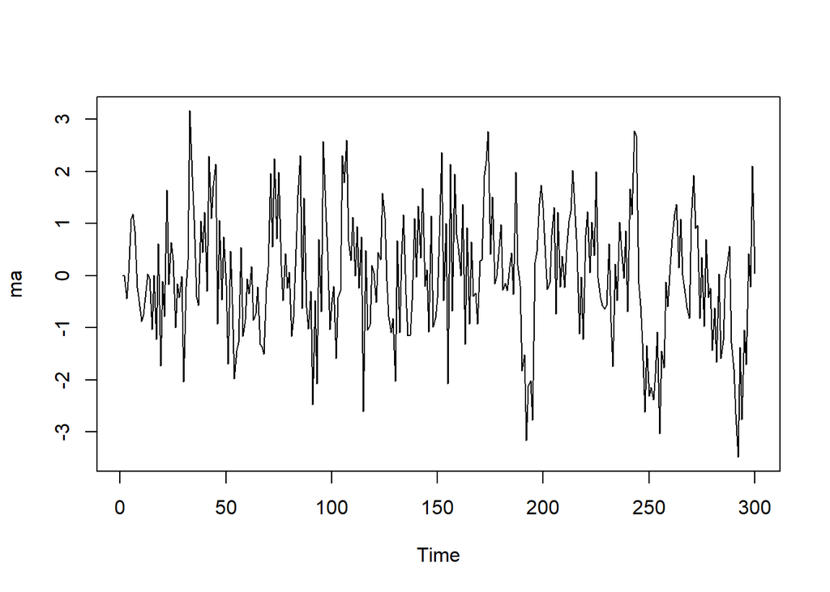

```r
ts.plot(ma)
```

Berdasarkan plot time series, data MA(2) yang dibangkitkan stasioner terhadap rataan.

### Plot ACF

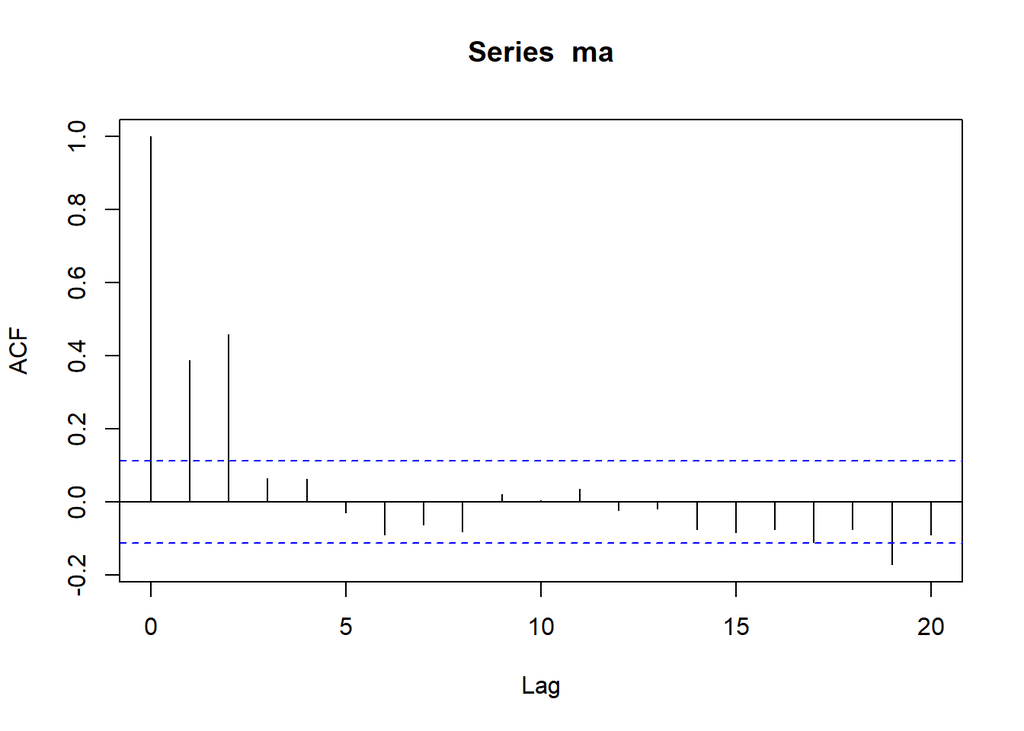

```r
acf(ma,lag.max = 20)
```

Berdasarkan plot ACF tersebut, terlihat bahwa plot ACF cuts off di lag 2.

### Plot PACF

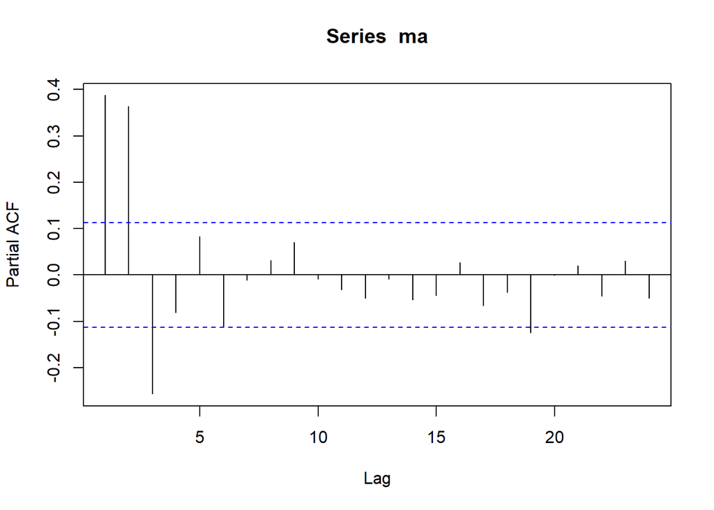

```r
pacf(ma)
```

Berdasarkan plot PACF tersebut, terlihat bahwa plot PACF cenderung tails off.

### Plot EACF

```r
TSA::eacf(ma)
```

```
## AR/MA
##   0 1 2 3 4 5 6 7 8 9 10 11 12 13
## 0 x x o o o o o o o o o  o  o  o
## 1 x x x o o o o o o o o  o  o  o
## 2 x x x x o o o o o o o  o  o  o
## 3 x x x x o o o o o o o  o  o  o
## 4 x o x o x o o o o o o  o  o  o
## 5 x o x o x o x o o o o  o  o  o
## 6 x x x o o o o x o o o  o  o  o
## 7 x x x o o o o o o o o  o  o  o
```

Berdasarkan pola segitiga nol pada plot EACF, terlihat bahwa segitiga nol berada pada ordo AR(0) dan ordo MA(2).

## Scatter Plot

### Korelasi Y_t dengan Y_t-1

```r
# Yt
yt_ma <- ma[-1]
yt_ma
```

```
##   [1]  0.0000000000 -0.4378027692  0.0495337742  1.0796257905  1.1768394330
##   [6]  0.8609250155 -0.2279847473 -0.4928789504 -0.8776346986 -0.7504264505
##  [11] -0.2940564597  0.0273416539 -0.0550745453 -1.0344468771  0.0095155322
##  [16] -1.2196096623  0.6161208229 -1.7329938436 -0.1129770585 -0.7811609982
##  [21]  1.6412032138 -0.1639375029  0.6322943004  0.3083980971 -0.9999819174
##  [26] -0.1595134346 -0.4135878569 -0.0204877958 -2.0379967576 -0.2180039719
##  [31]  0.2928352997  3.1604337087  1.9014310937  1.0709223381 -0.4049134670
##  [36] -0.5692948450  1.0476560584  0.4465201736  1.2132797151 -0.2963177621
##  [41]  2.2900239326  1.0961957188  1.7276760006  2.1312856095 -0.9200371687
##  [46]  1.0550300770 -0.4690400502  0.7447247439 -0.1834436819 -1.6971964164
##  [51]  0.4647826026 -0.5460251820 -1.9830066096 -1.4382090891 -1.2856419877
##  [56]  0.5407339236 -1.1667683899 -0.8453243913 -0.0608373709 -0.3489677855
##  [61]  0.1747782161 -0.8515808667 -0.7226078251 -0.2170966584 -1.3154403562
##  [66] -1.3665503425 -1.5054074100 -0.2226793832  0.1568280147  1.9598133413
##  [71]  0.5520349094  2.2431215766  0.7080484615  1.9883093543  0.2003571557
```

[output cut: 45 more lines]

```r
# Yt-1
yt_1_ma <- ma[-300]
yt_1_ma
```

```
##   [1]  0.0000000000  0.0000000000 -0.4378027692  0.0495337742  1.0796257905
##   [6]  1.1768394330  0.8609250155 -0.2279847473 -0.4928789504 -0.8776346986
##  [11] -0.7504264505 -0.2940564597  0.0273416539 -0.0550745453 -1.0344468771
##  [16]  0.0095155322 -1.2196096623  0.6161208229 -1.7329938436 -0.1129770585
##  [21] -0.7811609982  1.6412032138 -0.1639375029  0.6322943004  0.3083980971
##  [26] -0.9999819174 -0.1595134346 -0.4135878569 -0.0204877958 -2.0379967576
##  [31] -0.2180039719  0.2928352997  3.1604337087  1.9014310937  1.0709223381
##  [36] -0.4049134670 -0.5692948450  1.0476560584  0.4465201736  1.2132797151
##  [41] -0.2963177621  2.2900239326  1.0961957188  1.7276760006  2.1312856095
##  [46] -0.9200371687  1.0550300770 -0.4690400502  0.7447247439 -0.1834436819
##  [51] -1.6971964164  0.4647826026 -0.5460251820 -1.9830066096 -1.4382090891
##  [56] -1.2856419877  0.5407339236 -1.1667683899 -0.8453243913 -0.0608373709
##  [61] -0.3489677855  0.1747782161 -0.8515808667 -0.7226078251 -0.2170966584
##  [66] -1.3154403562 -1.3665503425 -1.5054074100 -0.2226793832  0.1568280147
##  [71]  1.9598133413  0.5520349094  2.2431215766  0.7080484615  1.9883093543
```

[output cut: 45 more lines]

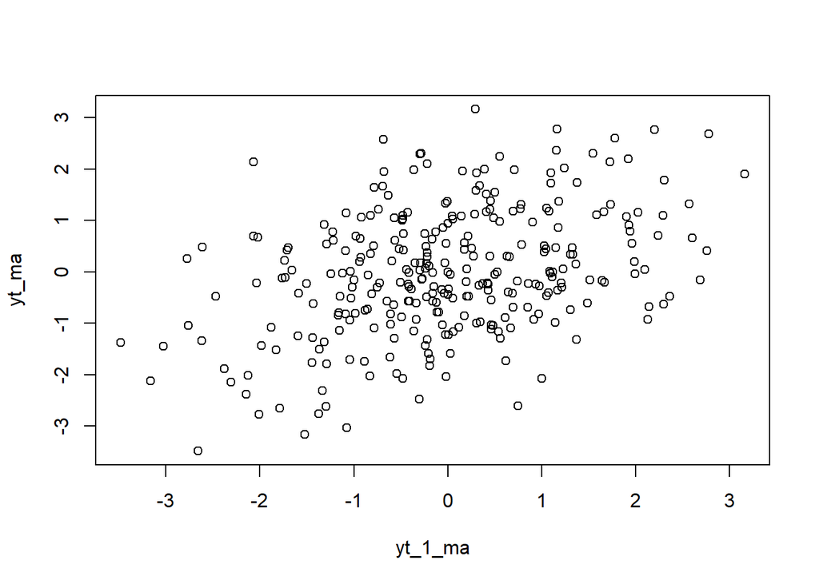

```r
plot(y=yt_ma,x=yt_1_ma)
```

```r
cor(yt_ma,yt_1_ma)
```

```
## [1] 0.3871896
```

Korelasi antara $Y_t$ dengan $Y_{t-1}$ dan $Y_{t-2}$ dari hasil simulasi dapat dibandingkan dengan perhitungan teoretis berikut:

$$\rho_1 = \frac{\theta_1 + \theta_1 \theta_2}{1 + \theta_1^2 +
\theta_2^2} =
\frac{0{,}4 + (0{,}4)(0{,}6)}{1 + (0{,}4)^2 + (0{,}6)^2} =
\frac{0{,}64}{1 + 0{,}16 + 0{,}36} =
\frac{0{,}64}{1{,}52} \approx 0{,}421$$

Nilai korelasi empiris berbeda dengan teoritis karena hasil simulasi itu bersifat acak, jadi nilai korelasi empiris (dari data hasil simulasi) tidak selalu identik dengan nilai teoretis.

### Korelasi Y_t dengan Y_t-2

```r
#Yt
yt_ma2 <- ma[-c(1,2)]
yt_ma2
```

```
##   [1] -0.4378027692  0.0495337742  1.0796257905  1.1768394330  0.8609250155
##   [6] -0.2279847473 -0.4928789504 -0.8776346986 -0.7504264505 -0.2940564597
##  [11]  0.0273416539 -0.0550745453 -1.0344468771  0.0095155322 -1.2196096623
##  [16]  0.6161208229 -1.7329938436 -0.1129770585 -0.7811609982  1.6412032138
##  [21] -0.1639375029  0.6322943004  0.3083980971 -0.9999819174 -0.1595134346
##  [26] -0.4135878569 -0.0204877958 -2.0379967576 -0.2180039719  0.2928352997
##  [31]  3.1604337087  1.9014310937  1.0709223381 -0.4049134670 -0.5692948450
##  [36]  1.0476560584  0.4465201736  1.2132797151 -0.2963177621  2.2900239326
##  [41]  1.0961957188  1.7276760006  2.1312856095 -0.9200371687  1.0550300770
##  [46] -0.4690400502  0.7447247439 -0.1834436819 -1.6971964164  0.4647826026
##  [51] -0.5460251820 -1.9830066096 -1.4382090891 -1.2856419877  0.5407339236
##  [56] -1.1667683899 -0.8453243913 -0.0608373709 -0.3489677855  0.1747782161
##  [61] -0.8515808667 -0.7226078251 -0.2170966584 -1.3154403562 -1.3665503425
##  [66] -1.5054074100 -0.2226793832  0.1568280147  1.9598133413  0.5520349094
##  [71]  2.2431215766  0.7080484615  1.9883093543  0.2003571557 -0.4738936946
```

[output cut: 45 more lines]

```r
#Yt-2
yt_2_ma <- ma[-c(299,300)]
yt_2_ma
```

```
##   [1]  0.0000000000  0.0000000000 -0.4378027692  0.0495337742  1.0796257905
##   [6]  1.1768394330  0.8609250155 -0.2279847473 -0.4928789504 -0.8776346986
##  [11] -0.7504264505 -0.2940564597  0.0273416539 -0.0550745453 -1.0344468771
##  [16]  0.0095155322 -1.2196096623  0.6161208229 -1.7329938436 -0.1129770585
##  [21] -0.7811609982  1.6412032138 -0.1639375029  0.6322943004  0.3083980971
##  [26] -0.9999819174 -0.1595134346 -0.4135878569 -0.0204877958 -2.0379967576
##  [31] -0.2180039719  0.2928352997  3.1604337087  1.9014310937  1.0709223381
##  [36] -0.4049134670 -0.5692948450  1.0476560584  0.4465201736  1.2132797151
##  [41] -0.2963177621  2.2900239326  1.0961957188  1.7276760006  2.1312856095
##  [46] -0.9200371687  1.0550300770 -0.4690400502  0.7447247439 -0.1834436819
##  [51] -1.6971964164  0.4647826026 -0.5460251820 -1.9830066096 -1.4382090891
##  [56] -1.2856419877  0.5407339236 -1.1667683899 -0.8453243913 -0.0608373709
##  [61] -0.3489677855  0.1747782161 -0.8515808667 -0.7226078251 -0.2170966584
##  [66] -1.3154403562 -1.3665503425 -1.5054074100 -0.2226793832  0.1568280147
##  [71]  1.9598133413  0.5520349094  2.2431215766  0.7080484615  1.9883093543
```

[output cut: 45 more lines]

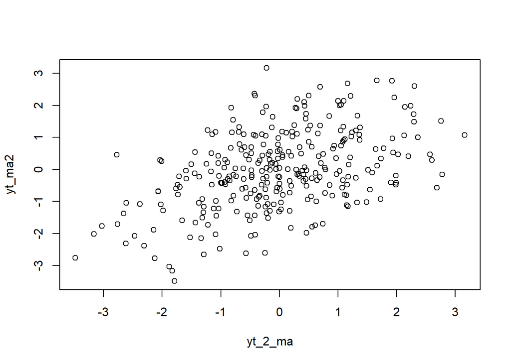

```r
plot(y=yt_ma2,x=yt_2_ma)
```

```r
cor(yt_ma2,yt_2_ma)
```

```
## [1] 0.4613566
```

$$\rho_2 = \frac{\theta_2}{1 + \theta_1^2 + \theta_2^2} =
\frac{0{,}6}{1 + (0{,}4)^2 + (0{,}6)^2} =
\frac{0{,}6}{1 + 0{,}16 + 0{,}36} =
\frac{0{,}6}{1{,}52} \approx 0{,}395$$

Nilai korelasi empiris berbeda dengan teoritis karena hasil simulasi itu bersifat acak, jadi nilai korelasi empiris (dari data hasil simulasi) tidak selalu identik dengan nilai teoretis.

### Korelasi Y_t dengan Y_t-3

```r
#Yt
yt_ma3 <- ma[-c(1,2,3)]
yt_ma3
```

```
##   [1]  0.0495337742  1.0796257905  1.1768394330  0.8609250155 -0.2279847473
##   [6] -0.4928789504 -0.8776346986 -0.7504264505 -0.2940564597  0.0273416539
##  [11] -0.0550745453 -1.0344468771  0.0095155322 -1.2196096623  0.6161208229
##  [16] -1.7329938436 -0.1129770585 -0.7811609982  1.6412032138 -0.1639375029
##  [21]  0.6322943004  0.3083980971 -0.9999819174 -0.1595134346 -0.4135878569
##  [26] -0.0204877958 -2.0379967576 -0.2180039719  0.2928352997  3.1604337087
##  [31]  1.9014310937  1.0709223381 -0.4049134670 -0.5692948450  1.0476560584
##  [36]  0.4465201736  1.2132797151 -0.2963177621  2.2900239326  1.0961957188
##  [41]  1.7276760006  2.1312856095 -0.9200371687  1.0550300770 -0.4690400502
##  [46]  0.7447247439 -0.1834436819 -1.6971964164  0.4647826026 -0.5460251820
##  [51] -1.9830066096 -1.4382090891 -1.2856419877  0.5407339236 -1.1667683899
##  [56] -0.8453243913 -0.0608373709 -0.3489677855  0.1747782161 -0.8515808667
##  [61] -0.7226078251 -0.2170966584 -1.3154403562 -1.3665503425 -1.5054074100
##  [66] -0.2226793832  0.1568280147  1.9598133413  0.5520349094  2.2431215766
##  [71]  0.7080484615  1.9883093543  0.2003571557 -0.4738936946  0.4274924149
```

[output cut: 45 more lines]

```r
#Yt-3
yt_3_ma <- ma[-c(298,299,300)]
yt_3_ma
```

```
##   [1]  0.0000000000  0.0000000000 -0.4378027692  0.0495337742  1.0796257905
##   [6]  1.1768394330  0.8609250155 -0.2279847473 -0.4928789504 -0.8776346986
##  [11] -0.7504264505 -0.2940564597  0.0273416539 -0.0550745453 -1.0344468771
##  [16]  0.0095155322 -1.2196096623  0.6161208229 -1.7329938436 -0.1129770585
##  [21] -0.7811609982  1.6412032138 -0.1639375029  0.6322943004  0.3083980971
##  [26] -0.9999819174 -0.1595134346 -0.4135878569 -0.0204877958 -2.0379967576
##  [31] -0.2180039719  0.2928352997  3.1604337087  1.9014310937  1.0709223381
##  [36] -0.4049134670 -0.5692948450  1.0476560584  0.4465201736  1.2132797151
##  [41] -0.2963177621  2.2900239326  1.0961957188  1.7276760006  2.1312856095
##  [46] -0.9200371687  1.0550300770 -0.4690400502  0.7447247439 -0.1834436819
##  [51] -1.6971964164  0.4647826026 -0.5460251820 -1.9830066096 -1.4382090891
##  [56] -1.2856419877  0.5407339236 -1.1667683899 -0.8453243913 -0.0608373709
##  [61] -0.3489677855  0.1747782161 -0.8515808667 -0.7226078251 -0.2170966584
##  [66] -1.3154403562 -1.3665503425 -1.5054074100 -0.2226793832  0.1568280147
##  [71]  1.9598133413  0.5520349094  2.2431215766  0.7080484615  1.9883093543
```

[output cut: 45 more lines]

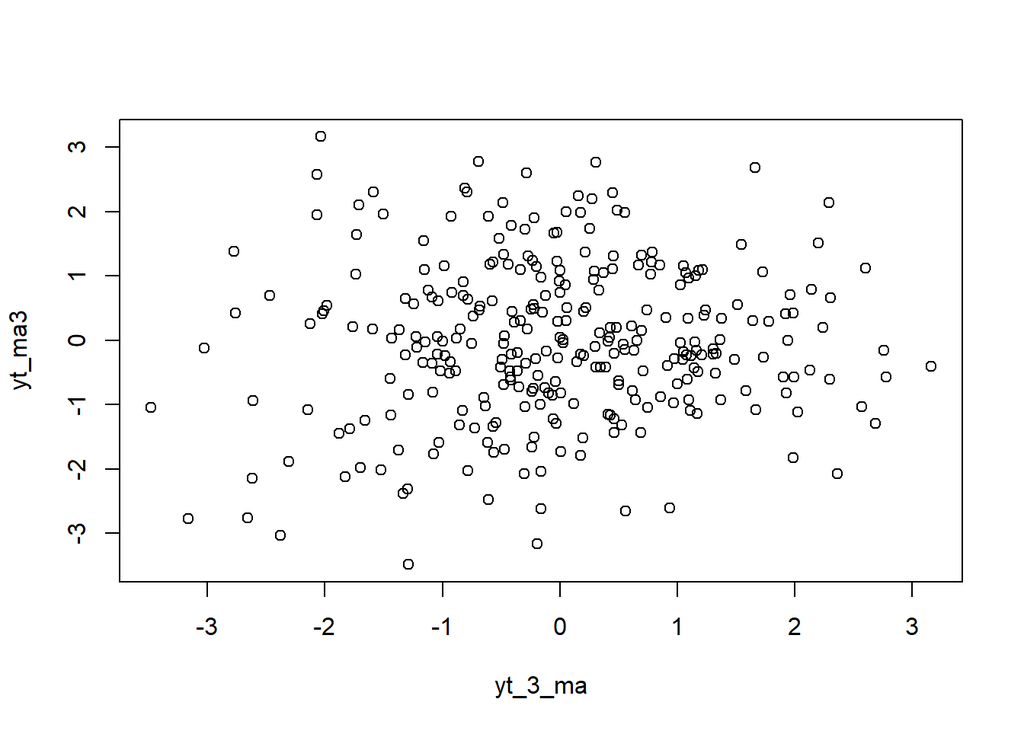

```r
plot(y=yt_ma3,x=yt_3_ma)
```

```r
cor(yt_ma3,yt_3_ma)
```

```
## [1] 0.06502543
```

# AR(2)

## Proses AR

Proses AR dapat dituliskan sebagai berikut:

$$y_t = c + e_t + \phi_1 Y_{t-1} + \phi_2 Y_{t-2} + \cdots + \phi_q
Y_{t-q}
= c + e_t + \sum_{i=1}^{p} \phi_i Y_{t-i}$$

Terlihat bahwa $Y_t$ berperan penting dalam pembangkitan proses AR.

## Model

```r
set.seed(1011)
```

Nilai-nilai selanjutnya dapat dicari melalui *loop*. Bentuk *loop* dapat dilihat dari rumus AR(2) yang akan dibangkitkan:

$$Y_t = e_t + 0{,}5 Y_{t-1} + 0{,}2 Y_{t-2}$$

```r
n <- 300
wn <- rnorm(n)
```

```r
# Bangkitkan AR(2) manual
ar2 <- rep(0, n)

for (i in 3:n) {
  ar2[i] <- wn[i] + 0.5 * ar2[i - 1] + 0.2 * ar2[i - 2]
}

ar2
```

```
##   [1]  0.000000000  0.000000000 -0.716929244  0.338091181  1.256820757
##   [6]  0.962470160  0.748251020  0.172509152 -0.108721087 -0.523176831
##  [11] -0.625656316 -0.272599640 -0.086640773 -0.309749314 -1.226760275
##  [16] -0.116846083 -1.114043848  0.024746832 -1.699323135 -0.725216931
##  [21] -0.638099530  1.079663475 -0.407852459  0.046072506  0.728276017
##  [26] -0.961793135 -0.432782694  0.017766088 -0.210242917 -2.342446867
##  [31] -0.455382885  0.638026006  2.399953927  1.559682165  0.934703705
##  [36]  0.365166084  0.160954716  1.533067581  0.818563545  1.093505276
##  [41]  0.251200303  2.591465165  1.818861805  1.617945896  2.944208637
##  [46]  0.052937821  1.304564989  0.963781674  0.953611322  0.221248350
##  [51] -1.343009011  0.764258135 -0.002489835 -2.619900842 -1.570444196
##  [56] -0.827941400 -0.223832477 -1.934720253 -1.497100957 -0.008012725
##  [61] -0.812402460 -0.705924279 -0.942389753 -0.985336407 -0.492891870
##  [66] -1.610481281 -1.916534702 -1.680503903 -0.678552745 -0.496467419
##  [71]  1.177301501  0.309548032  1.768532131  1.210790548  2.014586415
```

[output cut: 45 more lines]

Selain menggunakan cara di atas, pembangkitan proses AR dapat dilakukan dengan fungsi arima.sim() sebagai berikut.

```r
ar2_sim <- arima.sim(list(order = c(2, 0, 0), ar = c(0.5, 0.2)), n = 300)

ar2_sim
```

```
## Time Series:
## Start = 1
## End = 300
## Frequency = 1
##   [1]  2.38750636  1.98819948  0.31377712  0.59787606 -1.37692453 -1.50775155
##   [7] -2.74927111 -2.70781333 -1.13547531 -0.46694995 -0.70056256 -1.98247387
##  [13] -1.58513136 -2.01520048 -2.49841794 -2.91463439 -1.47566384 -1.02273998
##  [19] -0.09082525 -0.54326850 -2.46170523 -1.35920168 -1.67760865 -3.24068924
##  [25] -3.00162682 -2.80394110 -3.02086530 -2.14344676 -1.28446481  1.92836219
##  [31]  0.61868128 -0.54829097  1.03081619  1.94008035  1.40502861  1.22392364
##  [37] -0.70036989 -1.28082965 -1.87721927 -2.68366992 -2.37053053 -3.08105544
##  [43] -1.88281444  0.07046364 -0.73694603 -2.14491882 -1.47023687 -0.23466073
##  [49] -1.02954324 -0.56414520 -2.16030327 -3.42515730 -2.06495151 -2.68916613
##  [55] -2.59844482 -0.93908768 -1.54480940 -1.06449303 -1.46920828 -1.39789048
##  [61] -0.08358956 -0.59284049 -1.09308990  0.54173288 -0.89541093 -0.90832855
```

[output cut: 39 more lines]

## Plot

### Plot Time Series

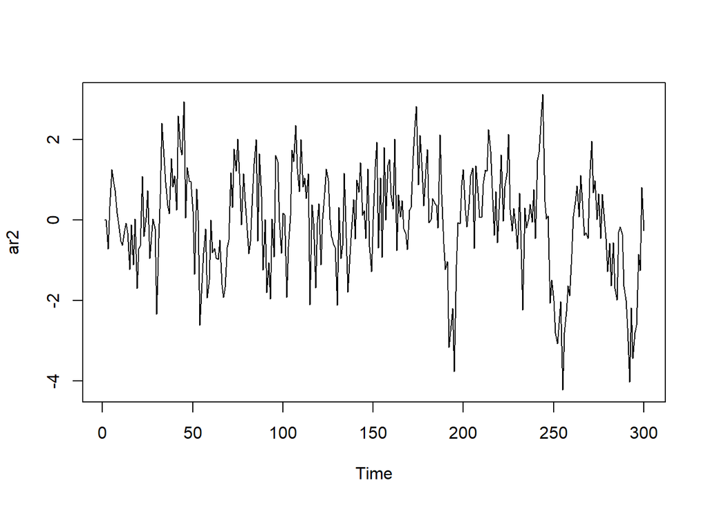

```r
ts.plot(ar2)
```

Berdasarkan plot time series tersebut terlihat bahwa data cenderung stasioner pada rataan.

### Plot ACF

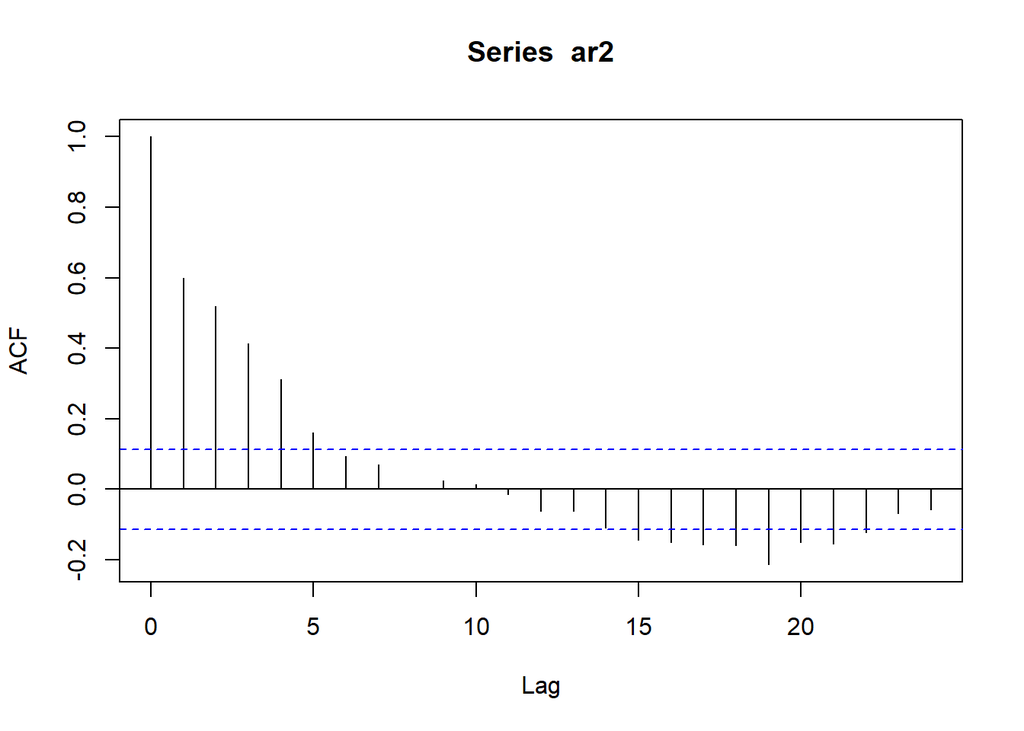

```r
acf(ar2)
```

Berdasarkan plot ACF tersebut terlihat bahwa plot ACF cenderung tails off.

### Plot PACF

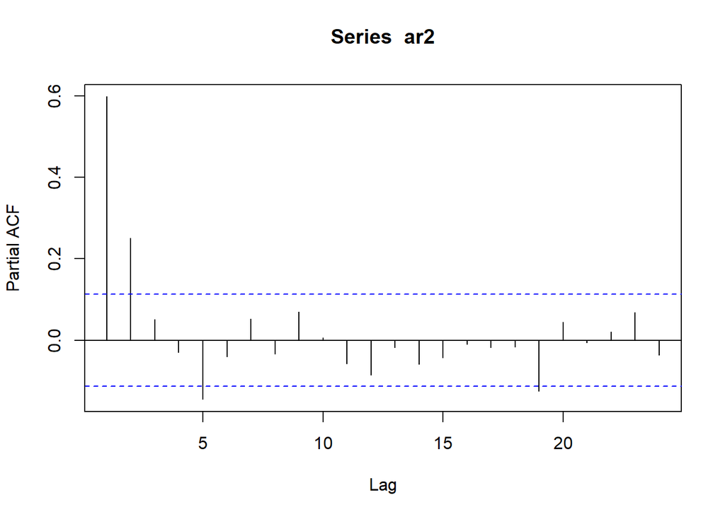

```r
pacf(ar2)
```

Berdasarkan plot PACF tersebut, terlihat bahwa plot PACF cuts off pada lag 2, sejalan dengan teori yang ada.

### Plot EACF

```r
TSA::eacf(ar2)
```

```
## AR/MA
##   0 1 2 3 4 5 6 7 8 9 10 11 12 13
## 0 x x x x x o o o o o o  o  o  o
## 1 x o o x o o o o o o o  o  o  o
## 2 x x o x o o o o o o o  o  o  o
## 3 x o x x o o o o o o o  o  o  o
## 4 x x x x o o o o o o o  o  o  o
## 5 x x x x o o o o o o o  o  o  o
## 6 x o o x o o o o o o o  o  o  o
## 7 x x o x o o o o o o o  o  o  o
```

## Scatter Plot

### Korelasi Y_t dengan Y_t-1

```r
#Yt
yt_ar <- ar2[-1]
yt_ar
```

```
##   [1]  0.000000000 -0.716929244  0.338091181  1.256820757  0.962470160
##   [6]  0.748251020  0.172509152 -0.108721087 -0.523176831 -0.625656316
##  [11] -0.272599640 -0.086640773 -0.309749314 -1.226760275 -0.116846083
##  [16] -1.114043848  0.024746832 -1.699323135 -0.725216931 -0.638099530
##  [21]  1.079663475 -0.407852459  0.046072506  0.728276017 -0.961793135
##  [26] -0.432782694  0.017766088 -0.210242917 -2.342446867 -0.455382885
##  [31]  0.638026006  2.399953927  1.559682165  0.934703705  0.365166084
##  [36]  0.160954716  1.533067581  0.818563545  1.093505276  0.251200303
##  [41]  2.591465165  1.818861805  1.617945896  2.944208637  0.052937821
##  [46]  1.304564989  0.963781674  0.953611322  0.221248350 -1.343009011
##  [51]  0.764258135 -0.002489835 -2.619900842 -1.570444196 -0.827941400
##  [56] -0.223832477 -1.934720253 -1.497100957 -0.008012725 -0.812402460
##  [61] -0.705924279 -0.942389753 -0.985336407 -0.492891870 -1.610481281
##  [66] -1.916534702 -1.680503903 -0.678552745 -0.496467419  1.177301501
##  [71]  0.309548032  1.768532131  1.210790548  2.014586415  0.868845661
```

[output cut: 45 more lines]

```r
#Yt-1
yt_1_ar <- ar2[-300]
yt_1_ar
```

```
##   [1]  0.000000000  0.000000000 -0.716929244  0.338091181  1.256820757
##   [6]  0.962470160  0.748251020  0.172509152 -0.108721087 -0.523176831
##  [11] -0.625656316 -0.272599640 -0.086640773 -0.309749314 -1.226760275
##  [16] -0.116846083 -1.114043848  0.024746832 -1.699323135 -0.725216931
##  [21] -0.638099530  1.079663475 -0.407852459  0.046072506  0.728276017
##  [26] -0.961793135 -0.432782694  0.017766088 -0.210242917 -2.342446867
##  [31] -0.455382885  0.638026006  2.399953927  1.559682165  0.934703705
##  [36]  0.365166084  0.160954716  1.533067581  0.818563545  1.093505276
##  [41]  0.251200303  2.591465165  1.818861805  1.617945896  2.944208637
##  [46]  0.052937821  1.304564989  0.963781674  0.953611322  0.221248350
##  [51] -1.343009011  0.764258135 -0.002489835 -2.619900842 -1.570444196
##  [56] -0.827941400 -0.223832477 -1.934720253 -1.497100957 -0.008012725
##  [61] -0.812402460 -0.705924279 -0.942389753 -0.985336407 -0.492891870
##  [66] -1.610481281 -1.916534702 -1.680503903 -0.678552745 -0.496467419
##  [71]  1.177301501  0.309548032  1.768532131  1.210790548  2.014586415
```

[output cut: 45 more lines]

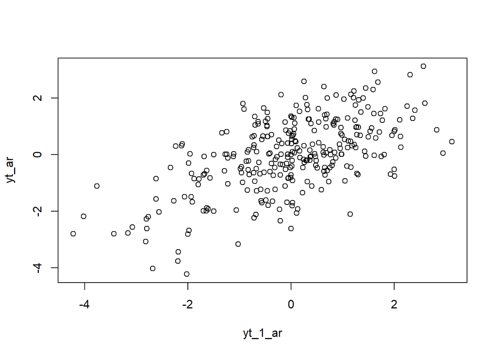

```r
plot(y=yt_ar,x=yt_1_ar)
```

Berdasarkan scatterplot tersebut, terlihat bahwa terdapat hubungan positif antara *{t} dengan* {t−1}.

```r
cor(yt_ar,yt_1_ar)
```

```
## [1] 0.5982319
```

Korelasi antara *{t} dengan* {t−1} dari hasil simulasi mendekati perhitungan teoritis, yaitu

$$\rho_1 = \frac{\phi_1}{1 - \phi_2} = \frac{0{,}5}{1 - 0{,}2} =
\frac{0{,}5}{0{,}8} = 0{,}625$$

### Korelasi Y_t dengan Y_t-2

```r
#Yt
yt_ar2 <- ar2[-c(1,2)]
yt_ar2
```

```
##   [1] -0.716929244  0.338091181  1.256820757  0.962470160  0.748251020
##   [6]  0.172509152 -0.108721087 -0.523176831 -0.625656316 -0.272599640
##  [11] -0.086640773 -0.309749314 -1.226760275 -0.116846083 -1.114043848
##  [16]  0.024746832 -1.699323135 -0.725216931 -0.638099530  1.079663475
##  [21] -0.407852459  0.046072506  0.728276017 -0.961793135 -0.432782694
##  [26]  0.017766088 -0.210242917 -2.342446867 -0.455382885  0.638026006
##  [31]  2.399953927  1.559682165  0.934703705  0.365166084  0.160954716
##  [36]  1.533067581  0.818563545  1.093505276  0.251200303  2.591465165
##  [41]  1.818861805  1.617945896  2.944208637  0.052937821  1.304564989
##  [46]  0.963781674  0.953611322  0.221248350 -1.343009011  0.764258135
##  [51] -0.002489835 -2.619900842 -1.570444196 -0.827941400 -0.223832477
##  [56] -1.934720253 -1.497100957 -0.008012725 -0.812402460 -0.705924279
##  [61] -0.942389753 -0.985336407 -0.492891870 -1.610481281 -1.916534702
##  [66] -1.680503903 -0.678552745 -0.496467419  1.177301501  0.309548032
##  [71]  1.768532131  1.210790548  2.014586415  0.868845661 -0.117602148
```

[output cut: 45 more lines]

```r
#Yt-2
yt_2_ar <- ar2[-c(299,300)]
yt_2_ar
```

```
##   [1]  0.000000000  0.000000000 -0.716929244  0.338091181  1.256820757
##   [6]  0.962470160  0.748251020  0.172509152 -0.108721087 -0.523176831
##  [11] -0.625656316 -0.272599640 -0.086640773 -0.309749314 -1.226760275
##  [16] -0.116846083 -1.114043848  0.024746832 -1.699323135 -0.725216931
##  [21] -0.638099530  1.079663475 -0.407852459  0.046072506  0.728276017
##  [26] -0.961793135 -0.432782694  0.017766088 -0.210242917 -2.342446867
##  [31] -0.455382885  0.638026006  2.399953927  1.559682165  0.934703705
##  [36]  0.365166084  0.160954716  1.533067581  0.818563545  1.093505276
##  [41]  0.251200303  2.591465165  1.818861805  1.617945896  2.944208637
##  [46]  0.052937821  1.304564989  0.963781674  0.953611322  0.221248350
##  [51] -1.343009011  0.764258135 -0.002489835 -2.619900842 -1.570444196
##  [56] -0.827941400 -0.223832477 -1.934720253 -1.497100957 -0.008012725
##  [61] -0.812402460 -0.705924279 -0.942389753 -0.985336407 -0.492891870
##  [66] -1.610481281 -1.916534702 -1.680503903 -0.678552745 -0.496467419
##  [71]  1.177301501  0.309548032  1.768532131  1.210790548  2.014586415
```

[output cut: 45 more lines]

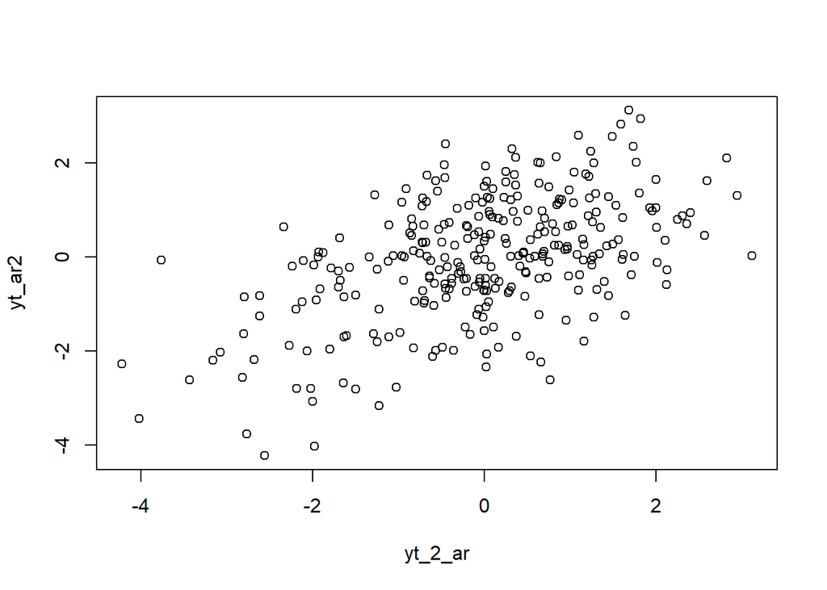

```r
plot(y=yt_ar2,x=yt_2_ar)
```

Berdasarkan scatterplot tersebut, terlihat bahwa terdapat hubungan positif antara *{t} dengan* {t−2}.

```r
cor(yt_ar2,yt_2_ar)
```

```
## [1] 0.5193029
```

Korelasi antara *{t} dengan* {t−2} dari hasil simulasi mendekati perhitungan teoritis, yaitu

$$\rho_2 = \phi_1 \cdot \rho_1 + \phi_2 = (0{,}5)(0{,}625) + 0{,}2 =
0{,}3125 + 0{,}2 = 0{,}5125$$

### Korelasi Y_t dengan Y_t-3

```r
#Yt
yt_ar3 <- ar2[-c(1,2,3)]
yt_ar3
```

```
##   [1]  0.338091181  1.256820757  0.962470160  0.748251020  0.172509152
##   [6] -0.108721087 -0.523176831 -0.625656316 -0.272599640 -0.086640773
##  [11] -0.309749314 -1.226760275 -0.116846083 -1.114043848  0.024746832
##  [16] -1.699323135 -0.725216931 -0.638099530  1.079663475 -0.407852459
##  [21]  0.046072506  0.728276017 -0.961793135 -0.432782694  0.017766088
##  [26] -0.210242917 -2.342446867 -0.455382885  0.638026006  2.399953927
##  [31]  1.559682165  0.934703705  0.365166084  0.160954716  1.533067581
##  [36]  0.818563545  1.093505276  0.251200303  2.591465165  1.818861805
##  [41]  1.617945896  2.944208637  0.052937821  1.304564989  0.963781674
##  [46]  0.953611322  0.221248350 -1.343009011  0.764258135 -0.002489835
##  [51] -2.619900842 -1.570444196 -0.827941400 -0.223832477 -1.934720253
##  [56] -1.497100957 -0.008012725 -0.812402460 -0.705924279 -0.942389753
##  [61] -0.985336407 -0.492891870 -1.610481281 -1.916534702 -1.680503903
##  [66] -0.678552745 -0.496467419  1.177301501  0.309548032  1.768532131
##  [71]  1.210790548  2.014586415  0.868845661 -0.117602148  1.152800772
```

[output cut: 45 more lines]

```r
#Yt-3
yt_3_ar <- ar2[-c(298,299,300)]
yt_3_ar
```

```
##   [1]  0.000000000  0.000000000 -0.716929244  0.338091181  1.256820757
##   [6]  0.962470160  0.748251020  0.172509152 -0.108721087 -0.523176831
##  [11] -0.625656316 -0.272599640 -0.086640773 -0.309749314 -1.226760275
##  [16] -0.116846083 -1.114043848  0.024746832 -1.699323135 -0.725216931
##  [21] -0.638099530  1.079663475 -0.407852459  0.046072506  0.728276017
##  [26] -0.961793135 -0.432782694  0.017766088 -0.210242917 -2.342446867
##  [31] -0.455382885  0.638026006  2.399953927  1.559682165  0.934703705
##  [36]  0.365166084  0.160954716  1.533067581  0.818563545  1.093505276
##  [41]  0.251200303  2.591465165  1.818861805  1.617945896  2.944208637
##  [46]  0.052937821  1.304564989  0.963781674  0.953611322  0.221248350
##  [51] -1.343009011  0.764258135 -0.002489835 -2.619900842 -1.570444196
##  [56] -0.827941400 -0.223832477 -1.934720253 -1.497100957 -0.008012725
##  [61] -0.812402460 -0.705924279 -0.942389753 -0.985336407 -0.492891870
##  [66] -1.610481281 -1.916534702 -1.680503903 -0.678552745 -0.496467419
##  [71]  1.177301501  0.309548032  1.768532131  1.210790548  2.014586415
```

[output cut: 45 more lines]

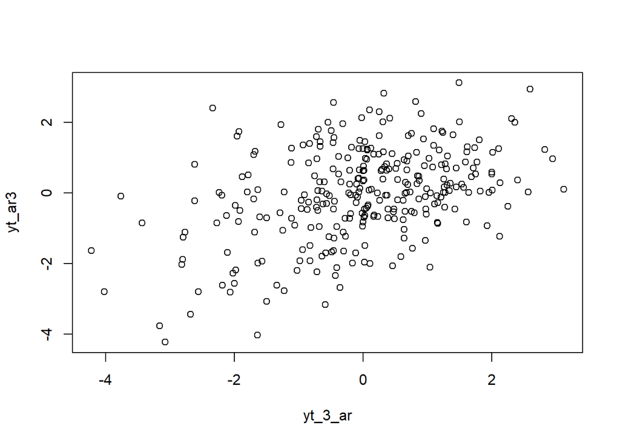

```r
plot(y=yt_ar3,x=yt_3_ar)
```

Berdasarkan scatterplot tersebut, terlihat bahwa terdapat hubungan positif antara *{t} dengan* {t−3}.

```r
cor(yt_ar3,yt_3_ar)
```

```
## [1] 0.4147299
```

Korelasi antara $Y_t$ dan $Y_{t-3}$ dari model AR(2) dihitung menggunakan rumus rekursif Yule-Walker:

$$\rho_3 = \phi_1 \cdot \rho_2 + \phi_2 \cdot \rho_1
= (0{,}5)(0{,}5125) + (0{,}2)(0{,}625)
= 0{,}25625 + 0{,}125
= 0{,}38125$$

Nilai korelasi empiris berbeda dengan teoritis karena hasil simulasi itu bersifat acak, jadi nilai korelasi empiris (dari data hasil simulasi) tidak selalu identik dengan nilai teoretis.

# ARMA(2,2)

Model ARMA(2,2) merupakan gabungan dari model autoregressive (AR) orde 2 dan moving average (MA) orde 2. Bentuk umum model ARMA adalah sebagai berikut:

$$y_t = c + \sum_{i=1}^{p} \phi_i y_{t-i} + \sum_{j=1}^{q} \theta_j
e_{t-j} + e_t$$

Sebagai contoh, jika diketahui parameter:

- $\phi_1 = 0.5$
- $\phi_2 = 0.2$
- $\theta_1 = 0.4$
- $\theta_2 = 0.6$

Maka model ARMA(2,2) menjadi:

$$y_t = c + 0.5\,y_{t-1} + 0.2\,y_{t-2} + 0.4\,e_{t-1} + 0.6\,e_{t-2} +
e_t$$

Untuk menghitung bagian AR dan MA:

Koefisien AR:
$$[\phi_1\ \phi_2] = [0.5\ \ 0.2]$$

Lag data sebelumnya:
$$[y_{t-1}\ \ y_{t-2}] = [2\ \ 3]$$

Maka bagian AR:
$$0.5 \cdot 2 + 0.2 \cdot 3 = 1.0 + 0.6 = 1.6$$

Begitu pula bagian MA, jika diketahui:
$$[\theta_1\ \theta_2] = [0.4\ \ 0.6] \quad \text{dan} \quad [e_{t-1}\ \
e_{t-2}] = [1\ \ 2]$$

Maka:
$$0.4 \cdot 1 + 0.6 \cdot (2) = 1.6$$

Sehingga nilai $y_t$ (tanpa e baru dan c):
$$y_t = 1.6 + 1.6 = 3.2$$

## Model

```r
set.seed(1011)
n <- 300
phi <- c(0.5, 0.2)        # AR(2)
theta <- c(0.4, 0.6)      # MA(2)
```

```r
phi <- c(0.5, 0.2)
y_lag <- c(2, 3)

# perkalian matriks
phi %*% y_lag
```

```
##      [,1]
## [1,]  1.6
```

```r
# perkalian element-wise
phi * y_lag
```

```
## [1] 1.0 0.6
```

```r
sum(phi * y_lag)
```

```
## [1] 1.6
```

```r
theta <- c(0.4, 0.6)
wn_lag <- c(1, 2)

# komponen MA
sum(theta * wn_lag)
```

```
## [1] 1.6
```

```r
sum(phi * y_lag) + sum(theta * wn_lag)
```

```
## [1] 3.2
```

Dari prinsip ini, dapat dibuat fungsi umum untuk membangkitkan data ARMA. Input dari fungsi adalah jumlah data yang akan dibangkitkan, koefisien MA, dan koefisien AR.

```r
# Fungsi untuk membangkitkan data ARMA(p,q)
arma.sim <- function(n, macoef, arcoef){
  manum <- length(macoef)
  arnum <- length(arcoef)
  stopifnot(manum < n & arnum < n)

  wn <- rnorm(n, sd = 0.5)
  init <- max(manum, arnum)

  arma <- wn[1:init]
  for(i in (init+1):n){
    mastart <- i - manum
    maend <- i - 1
    arstart <- i - arnum
    arend <- i - 1
    arma[i] <- sum(arcoef * arma[arstart:arend]) + sum(macoef * wn[mastart:maend]) + wn[i]
  }
  return(arma)
}
```

*Model ARMA(2,2) Manual*

```r
set.seed(1011)
n <- 300
wn <- rnorm(n)

phi1 <- 0.5
phi2 <- 0.2
theta1 <- 0.4
theta2 <- 0.6

y.arma <- rep(0, n)

for (i in 3:n){
  y.arma[i] <- phi1*y.arma[i-1] + phi2*y.arma[i-2] +
               theta1*wn[i-1] + theta2*wn[i-2] + wn[i]
}

head(y.arma)
```

```
## [1]  0.0000000  0.0000000 -0.4378028 -0.1693676  0.9073814  1.5966566
```

*Model ARMA(2,2) arma.sim*

```r
# Simulasi ARMA(2,2) dengan arma.sim
set.seed(1011)

arma22 <- arma.sim(
  n = 300,
  macoef = c(0.4, 0.6),
  arcoef = c(0.5, 0.2)
)

# Estimasi model ARMA(2,2)
arma22 |> arima(order = c(2,0,2))
```

```
##
## Call:
## arima(x = arma22, order = c(2, 0, 2))
##
## Coefficients:
##          ar1     ar2     ma1     ma2  intercept
##       0.1362  0.5785  0.5978  0.3134    -0.0158
## s.e.  0.0787  0.0719  0.0887  0.0608     0.1909
##
## sigma^2 estimated as 0.2522:  log likelihood = -219.94,  aic = 451.88
```

```r
arma_22 <- arima.sim(list(order=c(2,0,2), ar = c(0.5, 0.2), ma = c(0.4, 0.6)), n=300)
arma_22
```

```
## Time Series:
## Start = 1
## End = 300
## Frequency = 1
##   [1]  2.54178592  1.91647827 -0.94937696 -1.69969595 -4.17845038 -4.71211471
##   [7] -3.86811910 -2.54579437 -1.56860203 -2.54284928 -2.79844352 -3.83872597
##  [13] -4.25556827 -5.12311523 -4.14056331 -3.36178230 -1.38531661 -1.19324035
##  [19] -2.73350607 -2.66984357 -3.69831146 -4.72725295 -5.30446713 -5.94900493
##  [25] -5.94341750 -5.03415729 -3.95436250  0.12850835  0.61934738  0.85619894
##  [31]  1.18270863  2.02343230  2.79955050  2.94998332  0.63221675 -0.82662341
##  [37] -2.80977305 -4.20305540 -4.57033005 -5.63946960 -4.53755492 -2.53129540
##  [43] -1.83844924 -2.39741905 -2.77037202 -2.10970677 -2.00554965 -1.11675893
##  [49] -3.00368729 -4.62776572 -4.73119639 -5.57024111 -4.91308218 -3.59196529
##  [55] -3.47951136 -2.24586940 -2.82189113 -2.62426961 -1.52427072 -1.46501060
##  [61] -1.38037983 -0.25120737 -1.33457172 -0.94145319 -2.28314307 -3.70483715
```

[output cut: 39 more lines]

## Plot

### Plot Time Series

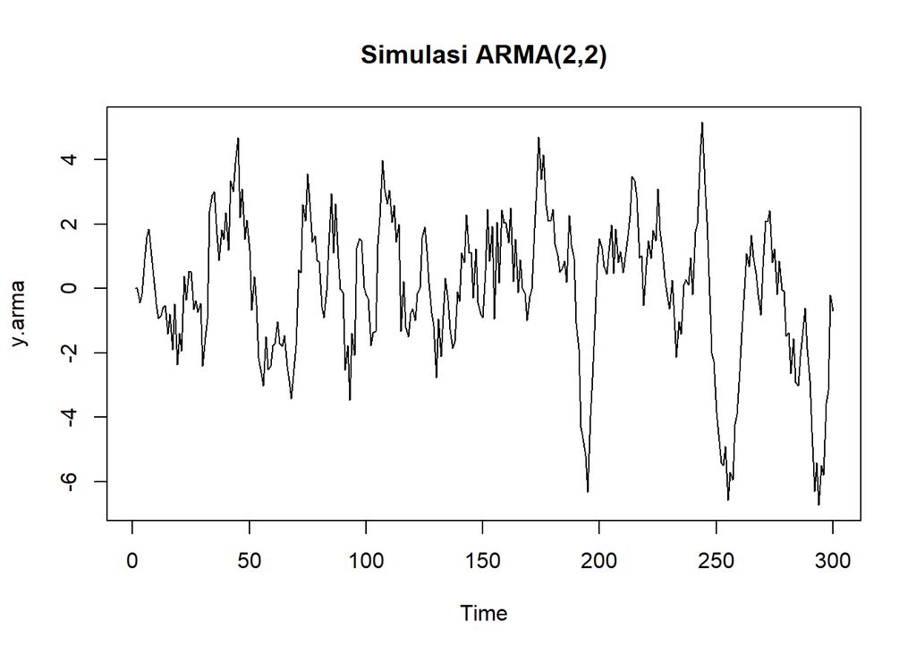

```r
ts.plot(y.arma, main = "Simulasi ARMA(2,2)", ylab = "y.arma", xlab = "Time")
```

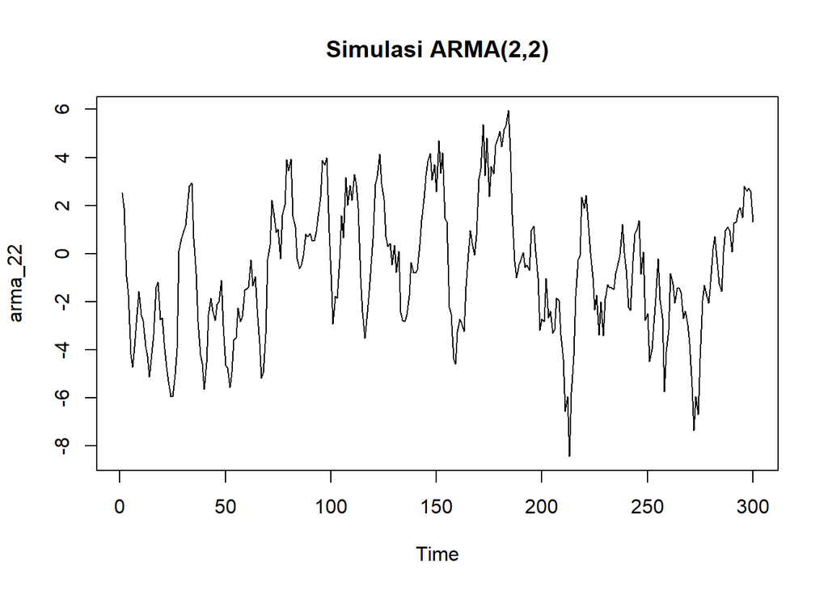

```r
ts.plot(arma_22, main = "Simulasi ARMA(2,2)", ylab = "arma_22", xlab = "Time")
```

Berdasarkan plot time series tersebut, terlihat bahwa model ARMA(2,2) cenderung stasioner dalam rataan.

### Plot ACF

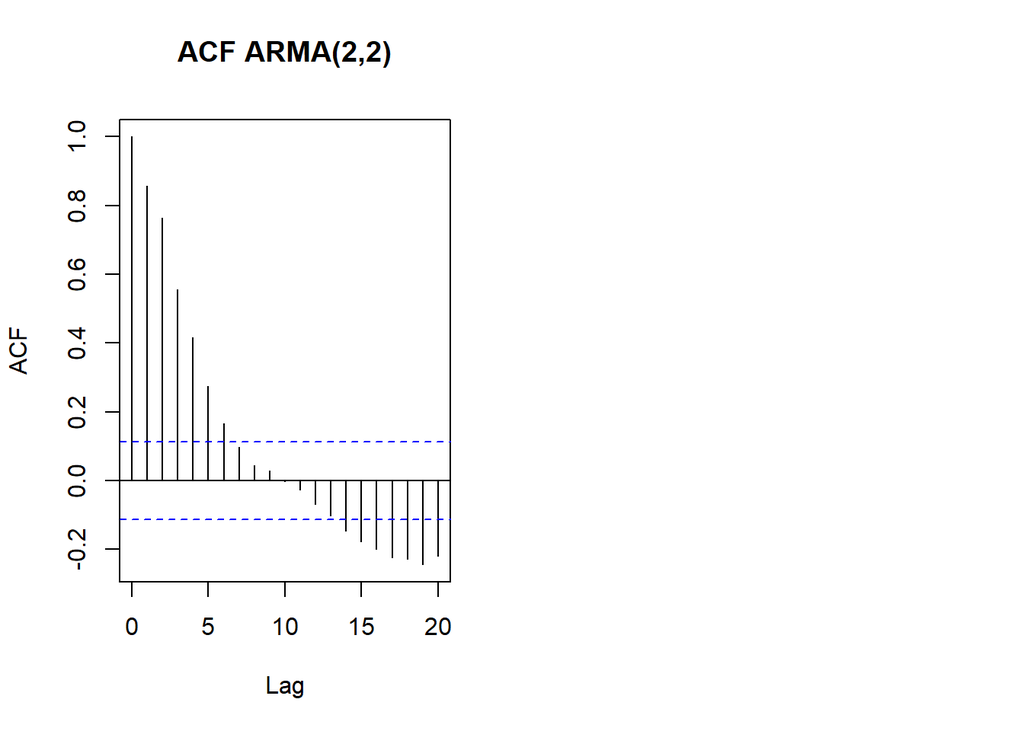

```r
par(mfrow = c(1,2))
acf(y.arma, lag.max = 20, main = "ACF ARMA(2,2)")
```

Berdasarkan plot ACF tersebut, terlihat bahwa model ARMA(2,2) hasil simulasi memiliki plot ACF yang tails off, sesuai dengan teori yang ada.

### Plot PACF

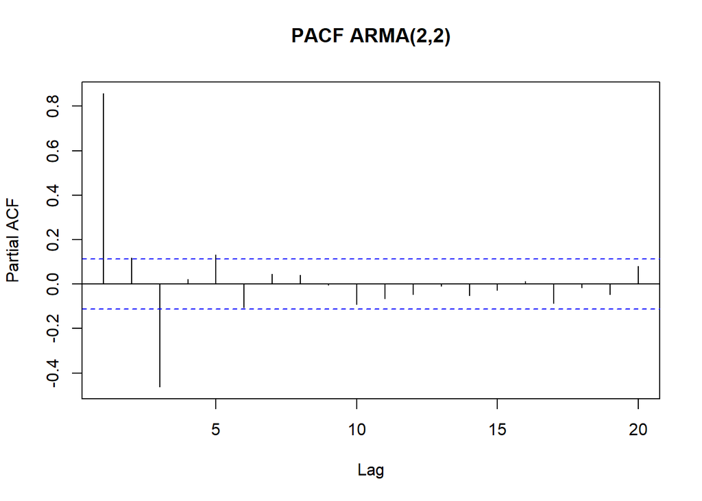

```r
pacf(y.arma, lag.max = 20, main = "PACF ARMA(2,2)")
```

### Plot EACF

```r
TSA::eacf(y.arma)
```

```
## AR/MA
##   0 1 2 3 4 5 6 7 8 9 10 11 12 13
## 0 x x x x x x o o o o o  o  o  x
## 1 x x o x o o o o o o o  o  o  o
## 2 x x x x o o o o o o o  o  o  o
## 3 o x x x o o o o o o o  o  o  o
## 4 x x o o o o o o o o o  o  o  o
## 5 x x o o o o o o o o o  o  o  o
## 6 x x x o o o o o o o o  o  o  o
## 7 x x x o o o o x o o o  o  o  o
```

```r
TSA::eacf(arma_22)
```

```
## AR/MA
##   0 1 2 3 4 5 6 7 8 9 10 11 12 13
## 0 x x x x x x x x x x x  x  x  x
## 1 x x o o o o o o o o o  o  o  o
## 2 x x o o o o o o o o o  o  o  o
## 3 x x x o o o o o o o o  o  o  o
## 4 x x x o o o o o o o o  o  o  o
## 5 x x x x o o o o o o o  o  o  o
## 6 x x o x o o x o o o o  o  o  o
## 7 x x x x x o x o o o o  o  o  o
```

Berdasarkan pola segitiga nol pada plot EACF, tidak jelas terlihat bahwa segitiga nol berada pada ordo AR(2) dan ordo MA(2).

## Scatter Plot

### Korelasi Y_t dengan Y_t-1

```r
#Yt
yt_arma <- arma_22[-1]
yt_arma
```

```
##   [1]  1.91647827 -0.94937696 -1.69969595 -4.17845038 -4.71211471 -3.86811910
##   [7] -2.54579437 -1.56860203 -2.54284928 -2.79844352 -3.83872597 -4.25556827
##  [13] -5.12311523 -4.14056331 -3.36178230 -1.38531661 -1.19324035 -2.73350607
##  [19] -2.66984357 -3.69831146 -4.72725295 -5.30446713 -5.94900493 -5.94341750
##  [25] -5.03415729 -3.95436250  0.12850835  0.61934738  0.85619894  1.18270863
##  [31]  2.02343230  2.79955050  2.94998332  0.63221675 -0.82662341 -2.80977305
##  [37] -4.20305540 -4.57033005 -5.63946960 -4.53755492 -2.53129540 -1.83844924
##  [43] -2.39741905 -2.77037202 -2.10970677 -2.00554965 -1.11675893 -3.00368729
##  [49] -4.62776572 -4.73119639 -5.57024111 -4.91308218 -3.59196529 -3.47951136
##  [55] -2.24586940 -2.82189113 -2.62426961 -1.52427072 -1.46501060 -1.38037983
##  [61] -0.25120737 -1.33457172 -0.94145319 -2.28314307 -3.70483715 -5.17522307
##  [67] -4.94902987 -3.33168932 -0.23864436  0.35048218  2.21790436  1.69994141
##  [73]  0.88359426  1.00747104 -0.20006774  1.61451532  2.01069895  3.91801652
##  [79]  3.45683560  3.93713085  1.55413753  1.11131010 -0.20911570 -0.62717373
##  [85] -0.47273323 -0.08981962  0.82570000  0.71613914  0.83670289  0.54556291
```

[output cut: 35 more lines]

```r
#Yt-1
yt_1_arma <- arma_22[-300]
yt_1_arma
```

```
##   [1]  2.54178592  1.91647827 -0.94937696 -1.69969595 -4.17845038 -4.71211471
##   [7] -3.86811910 -2.54579437 -1.56860203 -2.54284928 -2.79844352 -3.83872597
##  [13] -4.25556827 -5.12311523 -4.14056331 -3.36178230 -1.38531661 -1.19324035
##  [19] -2.73350607 -2.66984357 -3.69831146 -4.72725295 -5.30446713 -5.94900493
##  [25] -5.94341750 -5.03415729 -3.95436250  0.12850835  0.61934738  0.85619894
##  [31]  1.18270863  2.02343230  2.79955050  2.94998332  0.63221675 -0.82662341
##  [37] -2.80977305 -4.20305540 -4.57033005 -5.63946960 -4.53755492 -2.53129540
##  [43] -1.83844924 -2.39741905 -2.77037202 -2.10970677 -2.00554965 -1.11675893
##  [49] -3.00368729 -4.62776572 -4.73119639 -5.57024111 -4.91308218 -3.59196529
##  [55] -3.47951136 -2.24586940 -2.82189113 -2.62426961 -1.52427072 -1.46501060
##  [61] -1.38037983 -0.25120737 -1.33457172 -0.94145319 -2.28314307 -3.70483715
##  [67] -5.17522307 -4.94902987 -3.33168932 -0.23864436  0.35048218  2.21790436
##  [73]  1.69994141  0.88359426  1.00747104 -0.20006774  1.61451532  2.01069895
##  [79]  3.91801652  3.45683560  3.93713085  1.55413753  1.11131010 -0.20911570
##  [85] -0.62717373 -0.47273323 -0.08981962  0.82570000  0.71613914  0.83670289
```

[output cut: 35 more lines]

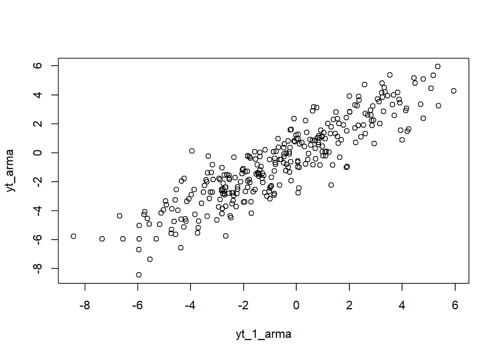

```r
plot(y=yt_arma,x=yt_1_arma)
```

Berdasarkan scatterplot tersebut, terlihat bahwa terdapat hubungan positif antara *{t} dengan* {t−1}.

```r
cor(yt_arma,yt_1_arma)
```

```
## [1] 0.897852
```

Korelasi antara *{t} dengan* {t−1} dari hasil simulasi mendekati perhitungan teoritis:

Untuk model ARMA(2,2) dengan parameter $\phi_1 = 0.5, \phi_2 = 0.2, \theta_1 = 0.4, \theta_2 = 0.6$,

$$Y_t = \sum_{j=0}^{\infty} \psi_j \, \varepsilon_{t-j}$$

dengan koefisien $\psi_j$ memenuhi rekursi:

$$\psi_0 = 1, \quad
\psi_k = \theta_k + \phi_1 \psi_{k-1} + \phi_2 \psi_{k-2}, \quad k \ge
1,$$

dengan $\theta_1 = 0.4, \theta_2 = 0.6, \theta_k = 0$ untuk $k > 2$.

Langkah perhitungan koefisien $\psi_j$:

$$\begin{aligned}
\psi_0 &= 1 \\
\psi_1 &= 0.4 + 0.5(1) = 0.9 \\
\psi_2 &= 0.6 + 0.5(0.9) + 0.2(1) = 1.25 \\
\psi_3 &= 0.5(1.25) + 0.2(0.9) = 0.805 \\
\psi_4 &= 0.5(0.805) + 0.2(1.25) = 0.6525 \\
\vdots &
\end{aligned}$$

Autokovarians teoretis:

$$\gamma_k = \sigma^2 \sum_{j=0}^{\infty} \psi_j \psi_{j+k}, \quad k \ge 0$$

$$\rho_k = \frac{\gamma_k}{\gamma_0}$$

$$\begin{aligned}
\rho_1 &\approx 0.859 \\
\end{aligned}$$

### Korelasi Y_t dengan Y_t-2

```r
#Yt
yt_arma2 <- arma_22[-c(1,2)]
yt_arma2
```

```
##   [1] -0.94937696 -1.69969595 -4.17845038 -4.71211471 -3.86811910 -2.54579437
##   [7] -1.56860203 -2.54284928 -2.79844352 -3.83872597 -4.25556827 -5.12311523
##  [13] -4.14056331 -3.36178230 -1.38531661 -1.19324035 -2.73350607 -2.66984357
##  [19] -3.69831146 -4.72725295 -5.30446713 -5.94900493 -5.94341750 -5.03415729
##  [25] -3.95436250  0.12850835  0.61934738  0.85619894  1.18270863  2.02343230
##  [31]  2.79955050  2.94998332  0.63221675 -0.82662341 -2.80977305 -4.20305540
##  [37] -4.57033005 -5.63946960 -4.53755492 -2.53129540 -1.83844924 -2.39741905
##  [43] -2.77037202 -2.10970677 -2.00554965 -1.11675893 -3.00368729 -4.62776572
##  [49] -4.73119639 -5.57024111 -4.91308218 -3.59196529 -3.47951136 -2.24586940
##  [55] -2.82189113 -2.62426961 -1.52427072 -1.46501060 -1.38037983 -0.25120737
##  [61] -1.33457172 -0.94145319 -2.28314307 -3.70483715 -5.17522307 -4.94902987
##  [67] -3.33168932 -0.23864436  0.35048218  2.21790436  1.69994141  0.88359426
##  [73]  1.00747104 -0.20006774  1.61451532  2.01069895  3.91801652  3.45683560
##  [79]  3.93713085  1.55413753  1.11131010 -0.20911570 -0.62717373 -0.47273323
##  [85] -0.08981962  0.82570000  0.71613914  0.83670289  0.54556291  0.52082179
```

[output cut: 35 more lines]

```r
#Yt-2
yt_2_arma <- arma_22[-c(299,300)]
yt_2_arma
```

```
##   [1]  2.54178592  1.91647827 -0.94937696 -1.69969595 -4.17845038 -4.71211471
##   [7] -3.86811910 -2.54579437 -1.56860203 -2.54284928 -2.79844352 -3.83872597
##  [13] -4.25556827 -5.12311523 -4.14056331 -3.36178230 -1.38531661 -1.19324035
##  [19] -2.73350607 -2.66984357 -3.69831146 -4.72725295 -5.30446713 -5.94900493
##  [25] -5.94341750 -5.03415729 -3.95436250  0.12850835  0.61934738  0.85619894
##  [31]  1.18270863  2.02343230  2.79955050  2.94998332  0.63221675 -0.82662341
##  [37] -2.80977305 -4.20305540 -4.57033005 -5.63946960 -4.53755492 -2.53129540
##  [43] -1.83844924 -2.39741905 -2.77037202 -2.10970677 -2.00554965 -1.11675893
##  [49] -3.00368729 -4.62776572 -4.73119639 -5.57024111 -4.91308218 -3.59196529
##  [55] -3.47951136 -2.24586940 -2.82189113 -2.62426961 -1.52427072 -1.46501060
##  [61] -1.38037983 -0.25120737 -1.33457172 -0.94145319 -2.28314307 -3.70483715
##  [67] -5.17522307 -4.94902987 -3.33168932 -0.23864436  0.35048218  2.21790436
##  [73]  1.69994141  0.88359426  1.00747104 -0.20006774  1.61451532  2.01069895
##  [79]  3.91801652  3.45683560  3.93713085  1.55413753  1.11131010 -0.20911570
##  [85] -0.62717373 -0.47273323 -0.08981962  0.82570000  0.71613914  0.83670289
```

[output cut: 35 more lines]

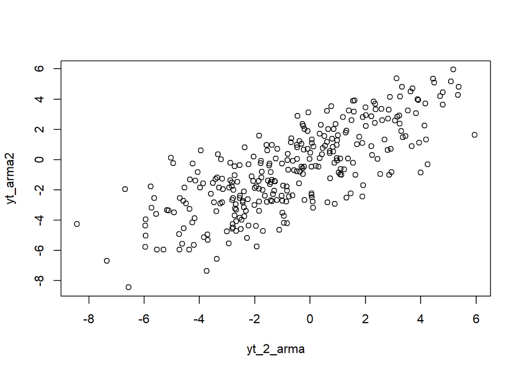

```r
plot(y=yt_arma2,x=yt_2_arma)
```

Berdasarkan scatterplot tersebut, terlihat bahwa terdapat hubungan positif antara *{t} dengan* {t−2}.

```r
cor(yt_arma2,yt_2_arma)
```

```
## [1] 0.7693763
```

Korelasi antara *{t} dengan* {t−2} dari hasil simulasi mendekati perhitungan teoritis:

Untuk model ARMA(2,2) dengan parameter $\phi_1 = 0.5, \phi_2 = 0.2, \theta_1 = 0.4, \theta_2 = 0.6$,

$$Y_t = \sum_{j=0}^{\infty} \psi_j \, \varepsilon_{t-j}$$

dengan koefisien $\psi_j$ memenuhi rekursi:

$$\psi_0 = 1, \quad
\psi_k = \theta_k + \phi_1 \psi_{k-1} + \phi_2 \psi_{k-2}, \quad k \ge
1,$$

dengan $\theta_1 = 0.4, \theta_2 = 0.6, \theta_k = 0$ untuk $k > 2$.

Langkah perhitungan koefisien $\psi_j$:

$$\begin{aligned}
\psi_0 &= 1 \\
\psi_1 &= 0.4 + 0.5(1) = 0.9 \\
\psi_2 &= 0.6 + 0.5(0.9) + 0.2(1) = 1.25 \\
\psi_3 &= 0.5(1.25) + 0.2(0.9) = 0.805 \\
\psi_4 &= 0.5(0.805) + 0.2(1.25) = 0.6525 \\
\vdots &
\end{aligned}$$

Autokovarians teoretis:

$$\gamma_k = \sigma^2 \sum_{j=0}^{\infty} \psi_j \psi_{j+k}, \quad k \ge 0$$

$$\rho_k = \frac{\gamma_k}{\gamma_0}$$

$$\begin{aligned}
\rho_2 &\approx 0.749\\
\end{aligned}$$

### Korelasi Y_t dengan Y_t-3

```r
#Yt
yt_arma3 <- arma_22[-c(1,2,3)]
yt_arma3
```

```
##   [1] -1.69969595 -4.17845038 -4.71211471 -3.86811910 -2.54579437 -1.56860203
##   [7] -2.54284928 -2.79844352 -3.83872597 -4.25556827 -5.12311523 -4.14056331
##  [13] -3.36178230 -1.38531661 -1.19324035 -2.73350607 -2.66984357 -3.69831146
##  [19] -4.72725295 -5.30446713 -5.94900493 -5.94341750 -5.03415729 -3.95436250
##  [25]  0.12850835  0.61934738  0.85619894  1.18270863  2.02343230  2.79955050
##  [31]  2.94998332  0.63221675 -0.82662341 -2.80977305 -4.20305540 -4.57033005
##  [37] -5.63946960 -4.53755492 -2.53129540 -1.83844924 -2.39741905 -2.77037202
##  [43] -2.10970677 -2.00554965 -1.11675893 -3.00368729 -4.62776572 -4.73119639
##  [49] -5.57024111 -4.91308218 -3.59196529 -3.47951136 -2.24586940 -2.82189113
##  [55] -2.62426961 -1.52427072 -1.46501060 -1.38037983 -0.25120737 -1.33457172
##  [61] -0.94145319 -2.28314307 -3.70483715 -5.17522307 -4.94902987 -3.33168932
##  [67] -0.23864436  0.35048218  2.21790436  1.69994141  0.88359426  1.00747104
##  [73] -0.20006774  1.61451532  2.01069895  3.91801652  3.45683560  3.93713085
##  [79]  1.55413753  1.11131010 -0.20911570 -0.62717373 -0.47273323 -0.08981962
##  [85]  0.82570000  0.71613914  0.83670289  0.54556291  0.52082179  0.92936063
```

[output cut: 35 more lines]

```r
#Yt-3
yt_3_arma <- arma_22[-c(298,299,300)]
yt_3_arma
```

```
##   [1]  2.54178592  1.91647827 -0.94937696 -1.69969595 -4.17845038 -4.71211471
##   [7] -3.86811910 -2.54579437 -1.56860203 -2.54284928 -2.79844352 -3.83872597
##  [13] -4.25556827 -5.12311523 -4.14056331 -3.36178230 -1.38531661 -1.19324035
##  [19] -2.73350607 -2.66984357 -3.69831146 -4.72725295 -5.30446713 -5.94900493
##  [25] -5.94341750 -5.03415729 -3.95436250  0.12850835  0.61934738  0.85619894
##  [31]  1.18270863  2.02343230  2.79955050  2.94998332  0.63221675 -0.82662341
##  [37] -2.80977305 -4.20305540 -4.57033005 -5.63946960 -4.53755492 -2.53129540
##  [43] -1.83844924 -2.39741905 -2.77037202 -2.10970677 -2.00554965 -1.11675893
##  [49] -3.00368729 -4.62776572 -4.73119639 -5.57024111 -4.91308218 -3.59196529
##  [55] -3.47951136 -2.24586940 -2.82189113 -2.62426961 -1.52427072 -1.46501060
##  [61] -1.38037983 -0.25120737 -1.33457172 -0.94145319 -2.28314307 -3.70483715
##  [67] -5.17522307 -4.94902987 -3.33168932 -0.23864436  0.35048218  2.21790436
##  [73]  1.69994141  0.88359426  1.00747104 -0.20006774  1.61451532  2.01069895
##  [79]  3.91801652  3.45683560  3.93713085  1.55413753  1.11131010 -0.20911570
##  [85] -0.62717373 -0.47273323 -0.08981962  0.82570000  0.71613914  0.83670289
```

[output cut: 35 more lines]

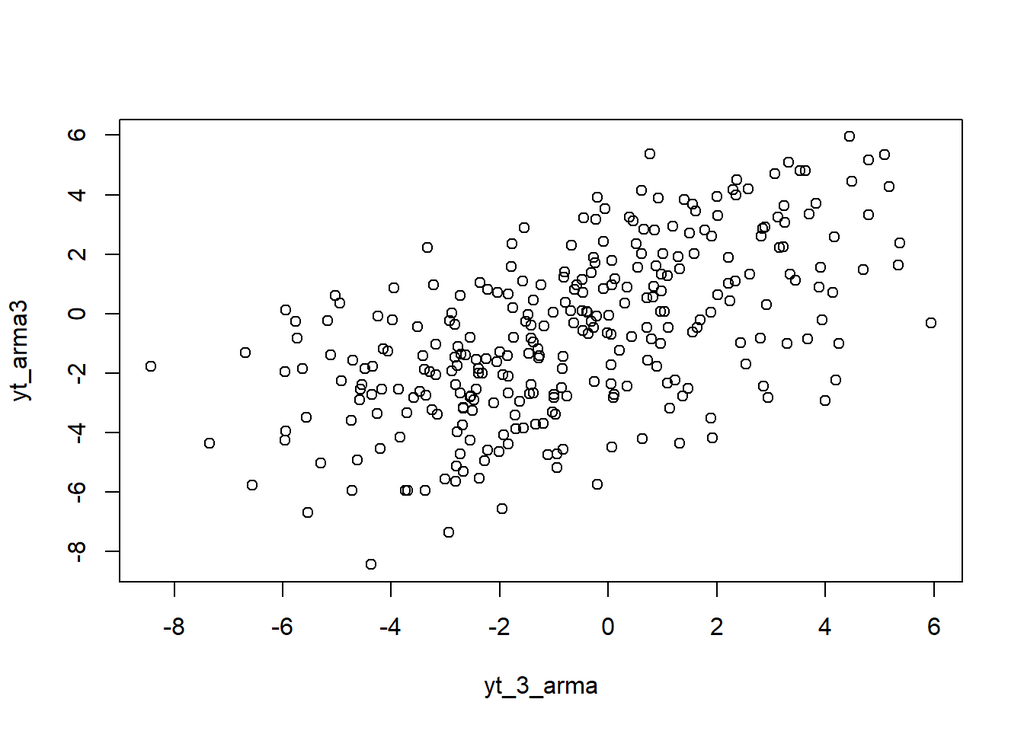

```r
plot(y=yt_arma3,x=yt_3_arma)
```

Berdasarkan scatterplot tersebut, terlihat bahwa terdapat hubungan positif antara *{t} dengan* {t−3}.

```r
cor(yt_arma3,yt_3_arma)
```

```
## [1] 0.5795372
```

Untuk model ARMA(2,2) dengan parameter $\phi_1 = 0.5, \phi_2 = 0.2, \theta_1 = 0.4, \theta_2 = 0.6$,

$$Y_t = \sum_{j=0}^{\infty} \psi_j \, \varepsilon_{t-j}$$

dengan koefisien $\psi_j$ memenuhi rekursi:

$$\psi_0 = 1, \quad
\psi_k = \theta_k + \phi_1 \psi_{k-1} + \phi_2 \psi_{k-2}, \quad k \ge
1,$$

dengan $\theta_1 = 0.4, \theta_2 = 0.6, \theta_k = 0$ untuk $k > 2$.

Langkah perhitungan koefisien $\psi_j$:

$$\begin{aligned}
\psi_0 &= 1 \\
\psi_1 &= 0.4 + 0.5(1) = 0.9 \\
\psi_2 &= 0.6 + 0.5(0.9) + 0.2(1) = 1.25 \\
\psi_3 &= 0.5(1.25) + 0.2(0.9) = 0.805 \\
\psi_4 &= 0.5(0.805) + 0.2(1.25) = 0.6525 \\
\vdots &
\end{aligned}$$

Autokovarians teoretis:

$$\gamma_k = \sigma^2 \sum_{j=0}^{\infty} \psi_j \psi_{j+k}, \quad k \ge 0$$

$$\rho_k = \frac{\gamma_k}{\gamma_0}$$

$$\begin{aligned}
\rho_3 &\approx 0.546\\
\end{aligned}$$